# Univariate Plots Section

```
## [1] 4898   13
```

白葡萄酒质量的数据集中包含4898种葡萄酒和13个变量。

```
## 'data.frame':    4898 obs. of  13 variables:
##  $ X                   : int  1 2 3 4 5 6 7 8 9 10 ...
##  $ fixed.acidity       : num  7 6.3 8.1 7.2 7.2 8.1 6.2 7 6.3 8.1 ...
##  $ volatile.acidity    : num  0.27 0.3 0.28 0.23 0.23 0.28 0.32 0.27 0.3 0.22 ...
##  $ citric.acid         : num  0.36 0.34 0.4 0.32 0.32 0.4 0.16 0.36 0.34 0.43 ...
##  $ residual.sugar      : num  20.7 1.6 6.9 8.5 8.5 6.9 7 20.7 1.6 1.5 ...
##  $ chlorides           : num  0.045 0.049 0.05 0.058 0.058 0.05 0.045 0.045 0.049 0.044 ...
##  $ free.sulfur.dioxide : num  45 14 30 47 47 30 30 45 14 28 ...
##  $ total.sulfur.dioxide: num  170 132 97 186 186 97 136 170 132 129 ...
##  $ density             : num  1.001 0.994 0.995 0.996 0.996 ...
##  $ pH                  : num  3 3.3 3.26 3.19 3.19 3.26 3.18 3 3.3 3.22 ...
##  $ sulphates           : num  0.45 0.49 0.44 0.4 0.4 0.44 0.47 0.45 0.49 0.45 ...
##  $ alcohol             : num  8.8 9.5 10.1 9.9 9.9 10.1 9.6 8.8 9.5 11 ...
##  $ quality             : int  6 6 6 6 6 6 6 6 6 6 ...
```

可以看出数据集中真正的有效变量只有12个，其中变量x只是排列的序号。

```
##        X        fixed.acidity    volatile.acidity  citric.acid
##  Min.   :   1   Min.   : 3.800   Min.   :0.0800   Min.   :0.0000
##  1st Qu.:1225   1st Qu.: 6.300   1st Qu.:0.2100   1st Qu.:0.2700
##  Median :2450   Median : 6.800   Median :0.2600   Median :0.3200
##  Mean   :2450   Mean   : 6.855   Mean   :0.2782   Mean   :0.3342
##  3rd Qu.:3674   3rd Qu.: 7.300   3rd Qu.:0.3200   3rd Qu.:0.3900
##  Max.   :4898   Max.   :14.200   Max.   :1.1000   Max.   :1.6600
##  residual.sugar     chlorides       free.sulfur.dioxide
##  Min.   : 0.600   Min.   :0.00900   Min.   :  2.00
##  1st Qu.: 1.700   1st Qu.:0.03600   1st Qu.: 23.00
##  Median : 5.200   Median :0.04300   Median : 34.00
##  Mean   : 6.391   Mean   :0.04577   Mean   : 35.31
##  3rd Qu.: 9.900   3rd Qu.:0.05000   3rd Qu.: 46.00
##  Max.   :65.800   Max.   :0.34600   Max.   :289.00
##  total.sulfur.dioxide    density             pH          sulphates
##  Min.   :  9.0        Min.   :0.9871   Min.   :2.720   Min.   :0.2200
##  1st Qu.:108.0        1st Qu.:0.9917   1st Qu.:3.090   1st Qu.:0.4100
##  Median :134.0        Median :0.9937   Median :3.180   Median :0.4700
##  Mean   :138.4        Mean   :0.9940   Mean   :3.188   Mean   :0.4898
##  3rd Qu.:167.0        3rd Qu.:0.9961   3rd Qu.:3.280   3rd Qu.:0.5500
##  Max.   :440.0        Max.   :1.0390   Max.   :3.820   Max.   :1.0800
##     alcohol         quality
##  Min.   : 8.00   Min.   :3.000
##  1st Qu.: 9.50   1st Qu.:5.000
##  Median :10.40   Median :6.000
##  Mean   :10.51   Mean   :5.878
##  3rd Qu.:11.40   3rd Qu.:6.000
##  Max.   :14.20   Max.   :9.000
```

从各个变量中可以看出density数据比较密集，其他字段的数据基本呈现出向左端聚集，而最右端只有个别的数据。

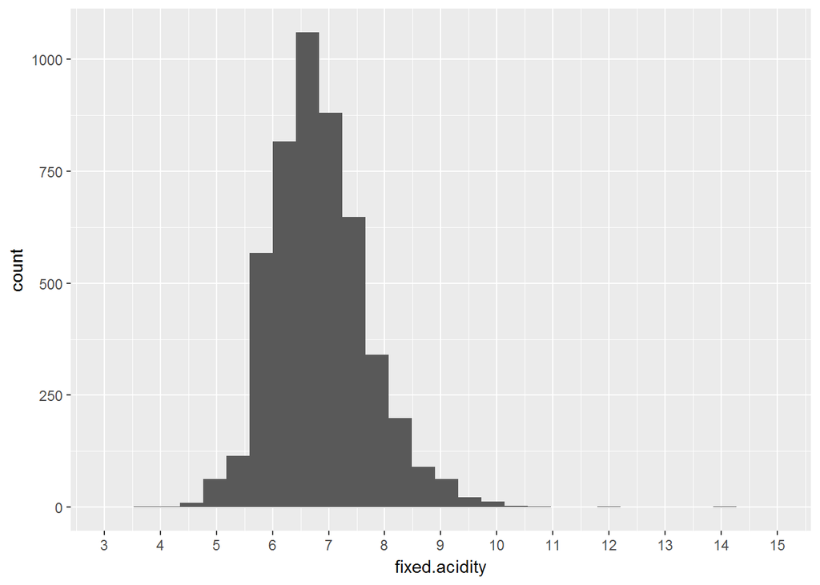

直方图中显示主要的数据集中在5-9区间段。

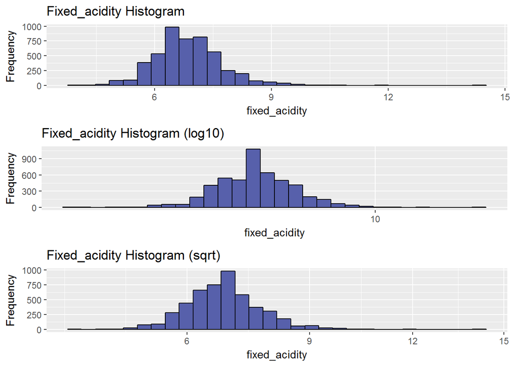

通过三种图进一步的进行分析，看数据集中的区间段在6-7.5范围。

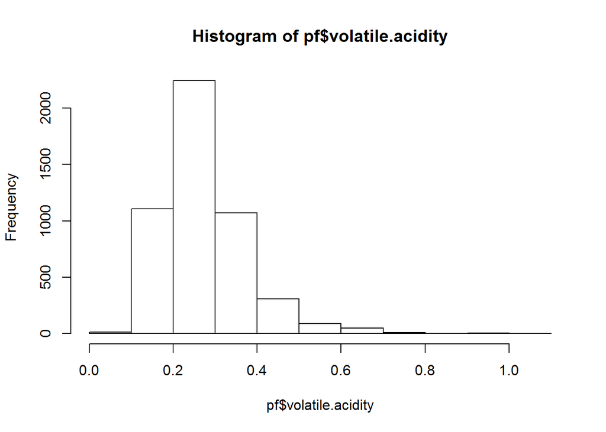

直方图显示0.1-0.4区间段中volatile.acidity该变量的数据较为集中。

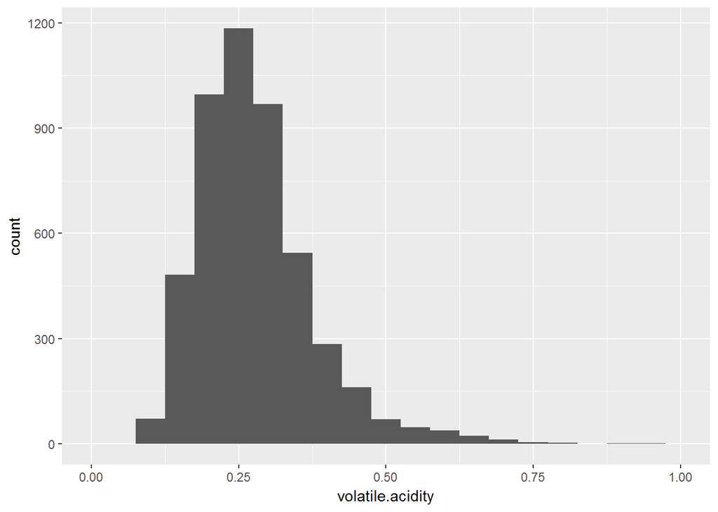

主要是比较同一变量两种作图的效果，图二较为直观。

```
##    Min. 1st Qu.  Median    Mean 3rd Qu.    Max.
##  0.0800  0.2100  0.2600  0.2782  0.3200  1.1000
```

可以看出volatile.acidity中位数0.26，均值0.2782都是在较小的值的范围内，后面在双变量分析中 可以结合volatile.acidity和fixed.acidity进行分析，它们有些共性。

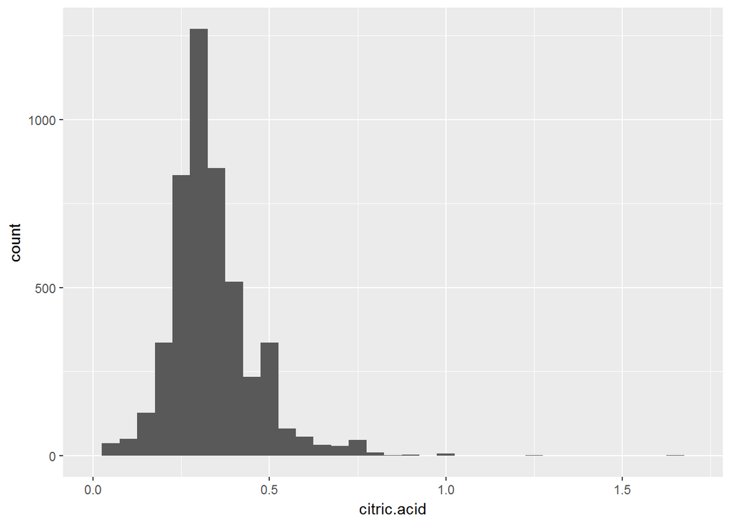

citric.acid变量的直方图。

```
##    Min. 1st Qu.  Median    Mean 3rd Qu.    Max.
##  0.0000  0.2700  0.3200  0.3342  0.3900  1.6600
```

```
##    Mode   FALSE    TRUE
## logical    4879      19
```

对零值做统计，有19条。

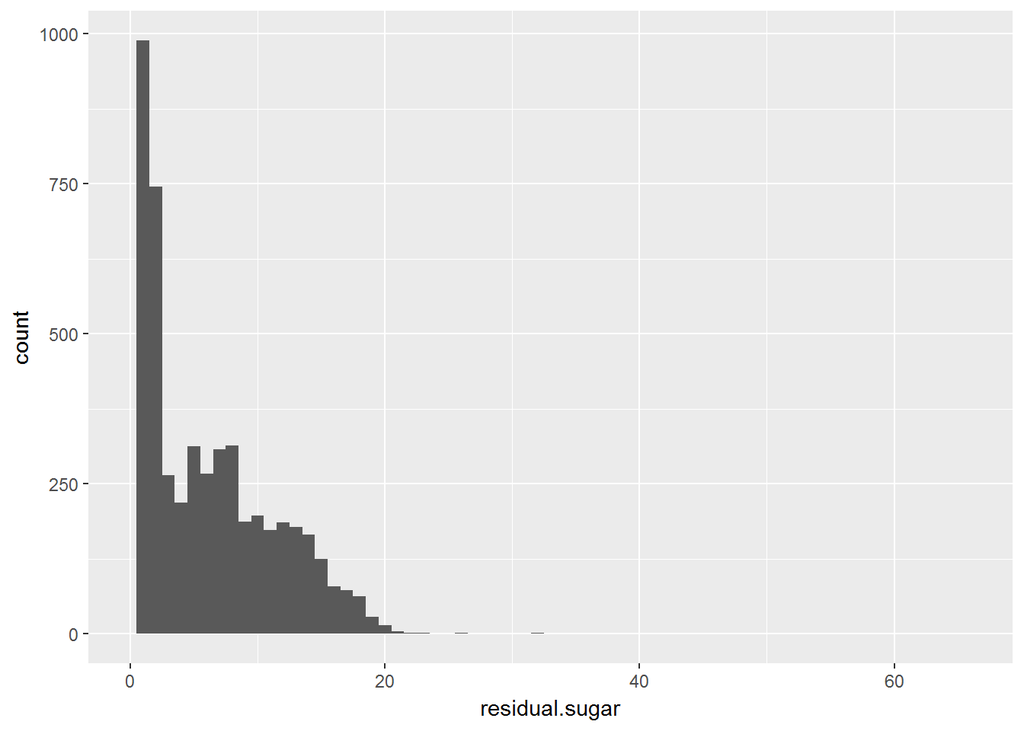

residual.sugar柱状图左边较为陡峭，右边数据降幅缓慢，整个数据走势呈现降低的趋势。

```
##    Min. 1st Qu.  Median    Mean 3rd Qu.    Max.
##   0.600   1.700   5.200   6.391   9.900  65.800
```

residual.sugar柱状图和summary显示该数据主要集中在6以下，越往后面数据的离散程度很高，最大值65.8偏离中位数和均值很多，双变量和多变量分析中可以单独把改点和其他的点挑出来作分析，看是不是异常值。

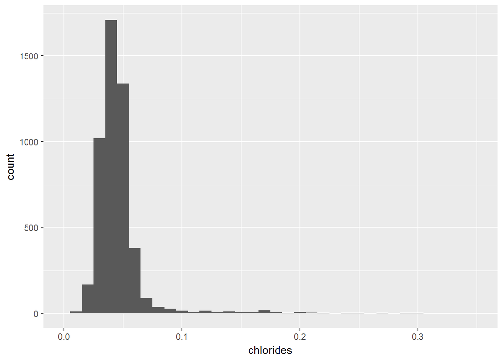

```
##    Min. 1st Qu.  Median    Mean 3rd Qu.    Max.
## 0.00900 0.03600 0.04300 0.04577 0.05000 0.34600
```

chlorides该变量的最大值为0.346，最小值为0.009，中位数为0.043，均值为0.04577。

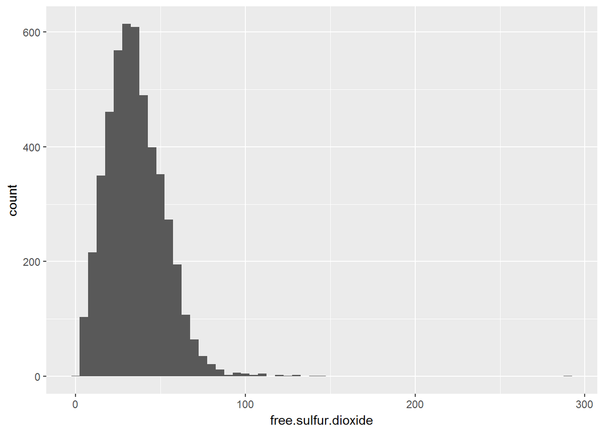

free.sulfur.dioxide该变量的柱状图显示，数据主要集中在100以下，还算符合正态分布的趋势。

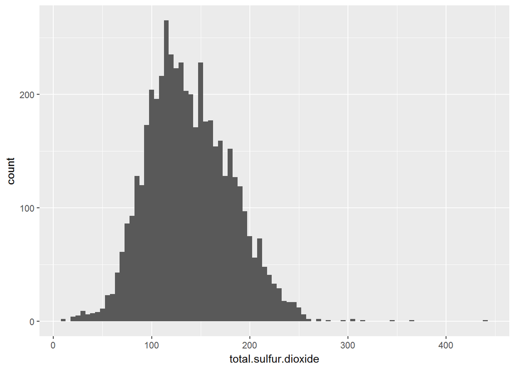

total.sulfur.dioxide数据整体呈现正太分布，个别的柱状图比较高，最大值偏离比较多。

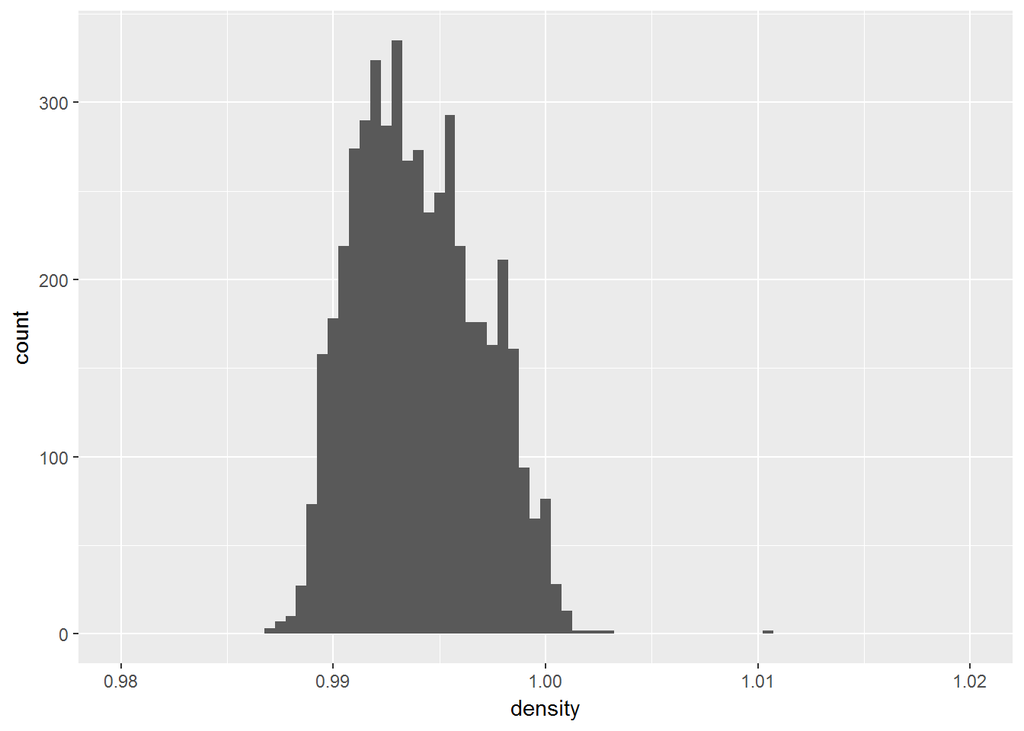

density数据比较集中，数据大部分分布在0.99至1.00之间，数据重叠区域比较多。

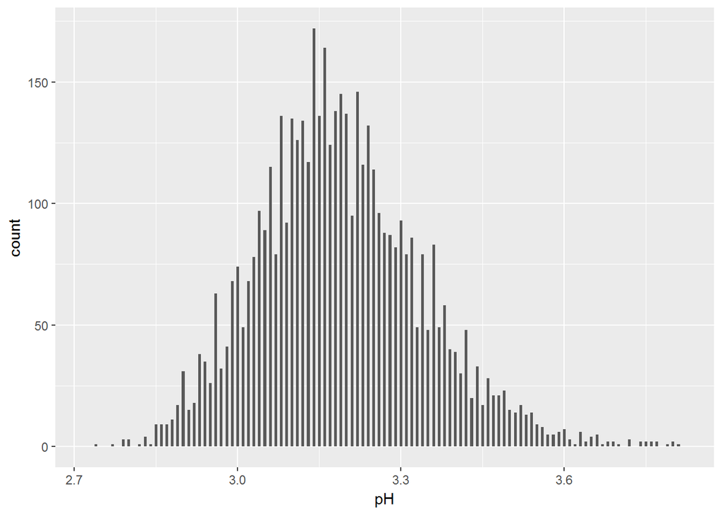

pH数据的分布的比较好，柱状图细长，整体较符合正太分布。

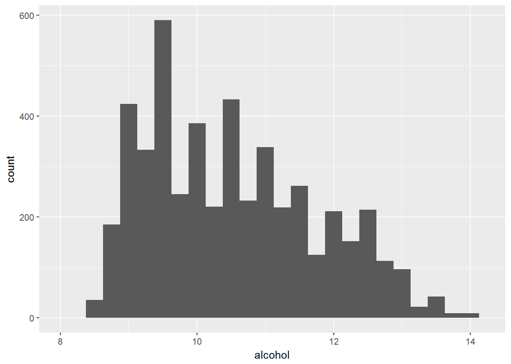

alcohol数据主要集中在9-13之间。

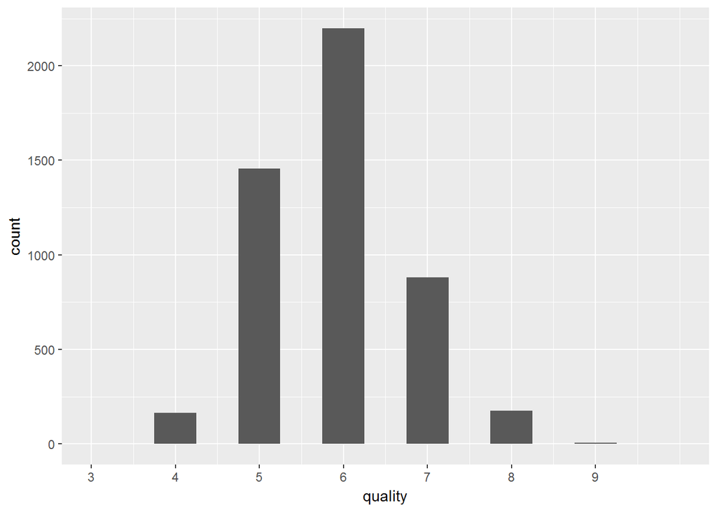

quality数据较为集中的是5,6,7整体的白酒质量是处于一个中等的水平内。

# Univariate Analysis

### What is the structure of your dataset?

白葡萄酒数据集中包含4898种葡萄酒和12个有效变量，分别为 “fixed.acidity”, “volatile.acidity”,“citric.acid”,“residual.sugar”,“chlorides”, “free.sulfur.dioxide”,“total.sulfur.dioxide”,“density”,“pH”,“sulphates”, “alcohol”h和“quality”。 “fixed.acidity”和“volatile.acidity”从后缀变量的名称来看，具有某种相似性，其中“fixed.acidity”的最大值是14.2，偏离均值和中位数很多，“citric.acid”介于3rd QU和Max之间，其他变量的值都是在均值左右的水平，而且最后quality的值为6，刚好在三分位数的位置，可以很明显的确定，该值14.2是个异常值点，实际的值可以小于该值，也可以具有相同的quality。仅次于同一变量14.2的数据是11.8,“residual.sugar”低于10个点，“free.sulfur.dioxide”和 “total.sulfur.dioxide”分别低于18个点和33个点，其他变量相差不大，最后的quality是3(最差的结果),“residual.sugar”该变量相差的比例最大，可能是它对最后的quality起到了一定的作用。 “volatile.acidity”的最大值为1.1，只有两个变量的值pH和alcohol高于三分位值，其他的变量值均是在均值和中位数范围左右，最后的结果quality是4，属于结果偏差的范围。

### What is/are the main feature(s) of interest in your dataset?

数据集中主要是想探究哪些变量能够最后影响quality，其中density变量的数据较为密集，离散度很小，真正影响其质量的只有11个有效变量，可以构建影响quality的变量模型进行进一步的探究。

### What other features in the dataset do you think will help support your investigation into your feature(s) of interest?

从某些变量的离散程度比较高的点，最大值和最小值等来探索某个单一变量的改变最后对quality的影响，也可以反过来进行，就quality评价最好的几组和最差的几组评分，再反向找对应该组其他变量的差异，从而推出影响quanlity的变量。

### Did you create any new variables from existing variables in the dataset?

变量 “volatile.acidity”和“citric.acid”都是某种酸，数据大小差异不多，就创建新的变量“acidity”,新的变量和quality之间的关系。

### Of the features you investigated, were there any unusual distributions? Did you perform any operations on the data to tidy, adjust, or change the form of the data? If so, why did you do this?

# Bivariate Plots Section

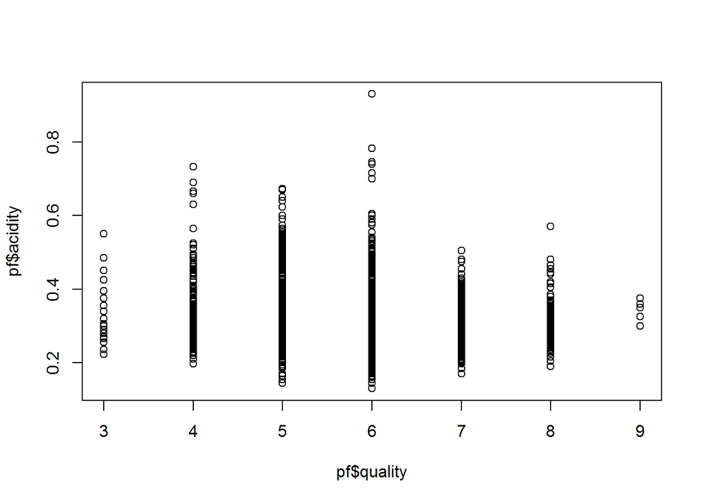

```
## [1] 4898   14
```

创建新的变量acidity，并做新的变量acidity和quality的散点图，可以看出变量为14个。

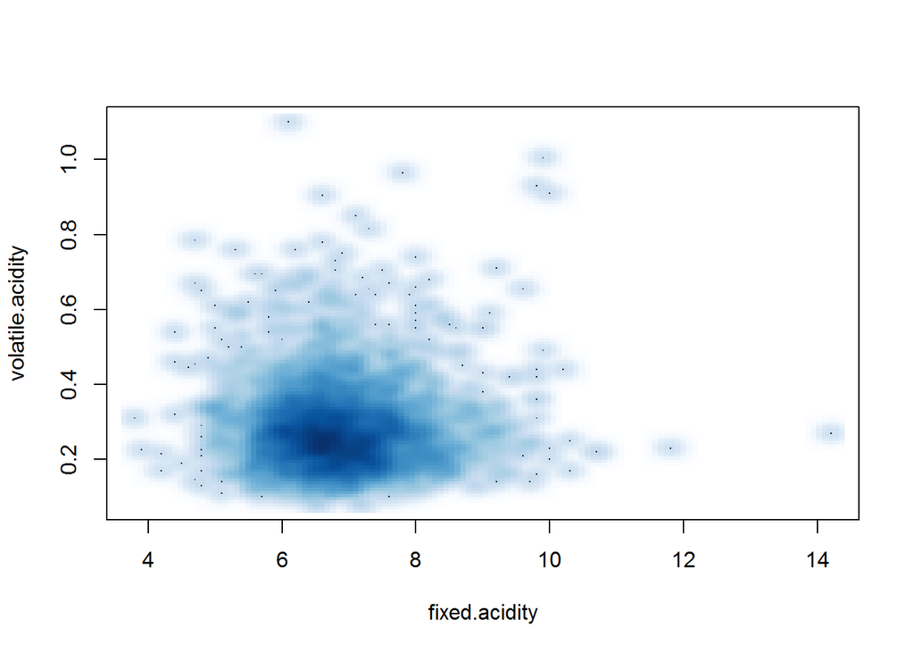

图中数据聚集由少到多，对应的是图的颜色由浅入深。这种渐变颜色的图较单纯的散点图更为直观，视觉效果更好。

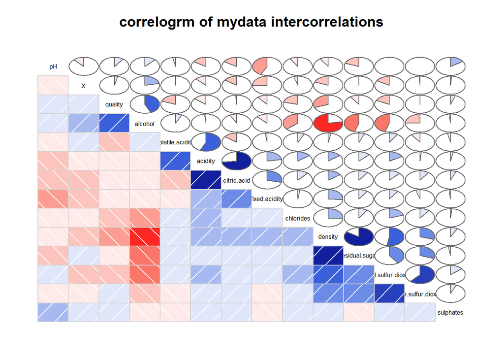

左下部分长方形图，两两之间呈正相关是蓝色，相关程度即是颜色由浅入深，里面的白色线段表示表示的是两变量呈现正相关，反之。右上部分的饼图，显示两个变量的相关关系程度。根据图中显示呈正相关较为明显的两个变量是residual.sugar和density，负相关较为明显的两个变量是density和alcohol。

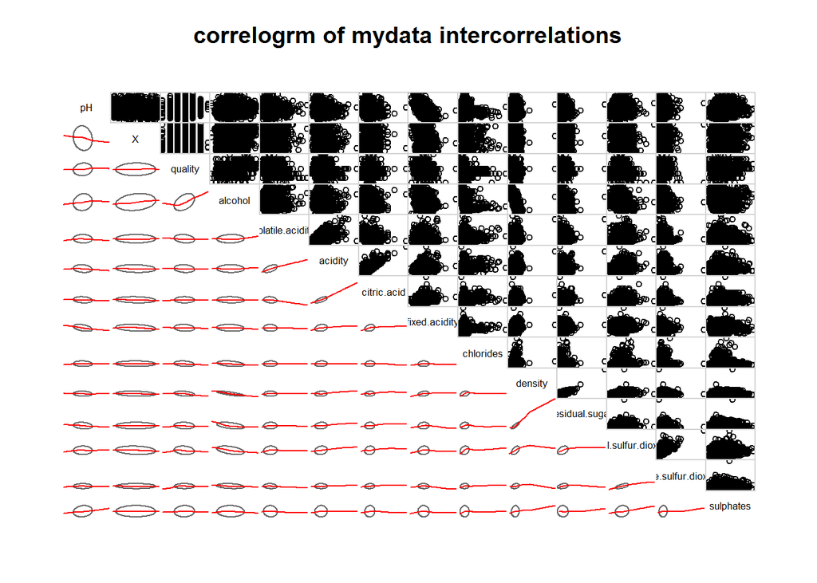

左下部分的拟合曲线呈现水平的居多，拟合的效果不是很好。右上部分是其两两变量的散点图。

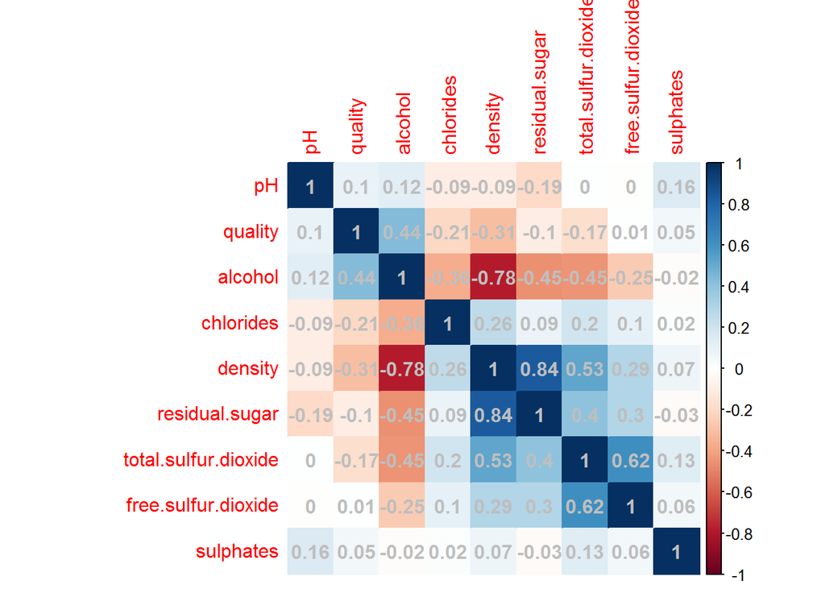

显示9个变量之间的相关系数，相关程度越高颜色越深，呈正相关最大的为0.84，负相关最大的为0.78。

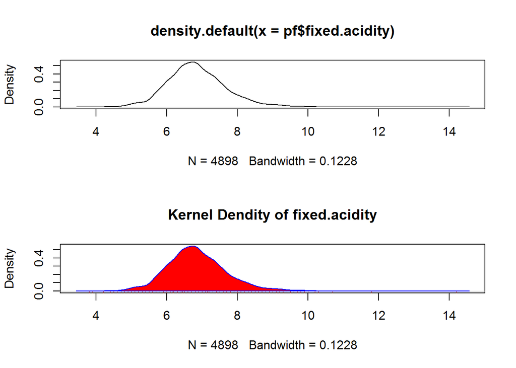

核密度曲线图并加了颜色。

[figure not shown]

pf$quality变量的核密度曲线。

```
##
## Call:
## lm(formula = residual.sugar ~ density, data = pf)
##
## Residuals:
##     Min      1Q  Median      3Q     Max
## -9.8434 -1.9070 -0.0151  1.9208 12.8899
##
## Coefficients:
##             Estimate Std. Error t value Pr(>|t|)
## (Intercept) -1407.85      13.11  -107.4   <2e-16 ***
## density      1422.74      13.19   107.9   <2e-16 ***
## ---
## Signif. codes:  0 '***' 0.001 '**' 0.01 '*' 0.05 '.' 0.1 ' ' 1
##
## Residual standard error: 2.76 on 4896 degrees of freedom
## Multiple R-squared:  0.7039, Adjusted R-squared:  0.7038
## F-statistic: 1.164e+04 on 1 and 4896 DF,  p-value: < 2.2e-16
```

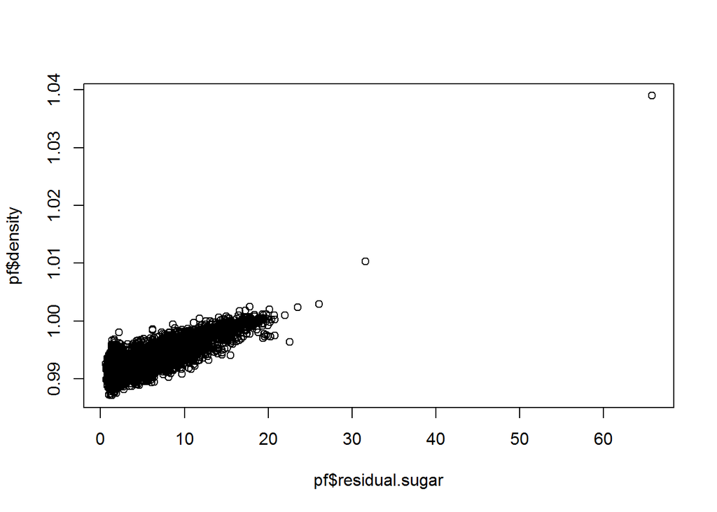

Adjusted R-squared: 0.7038，“residual.sugar”和“density”变量的相关性较好,通过输出的结果可以预测等式： residual.sugar = -1407.85 + 1422.74density

```
##
## Call:
## lm(formula = residual.sugar ~ density + I(density^2), data = pf)
##
## Residuals:
##      Min       1Q   Median       3Q      Max
## -24.5122  -1.8659   0.0004   1.8557  12.9995
##
## Coefficients:
##              Estimate Std. Error t value Pr(>|t|)
## (Intercept)      9114       1320   6.905 5.65e-12 ***
## density        -19716       2652  -7.436 1.22e-13 ***
## I(density^2)    10617       1332   7.972 1.92e-15 ***
## ---
## Signif. codes:  0 '***' 0.001 '**' 0.01 '*' 0.05 '.' 0.1 ' ' 1
##
## Residual standard error: 2.743 on 4895 degrees of freedom
## Multiple R-squared:  0.7077, Adjusted R-squared:  0.7075
## F-statistic:  5925 on 2 and 4895 DF,  p-value: < 2.2e-16
```

多项式的回归，拟合效果不是很好，Adjusted R-squared: 0.7075 提高的不多。

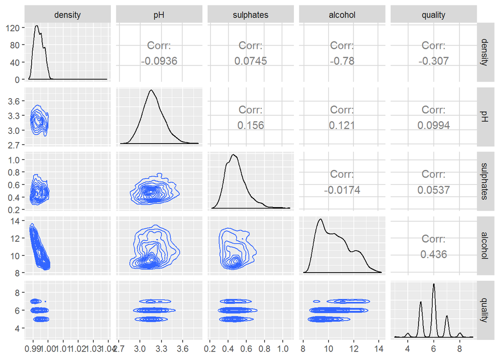

另外一种两变量的拟合图。

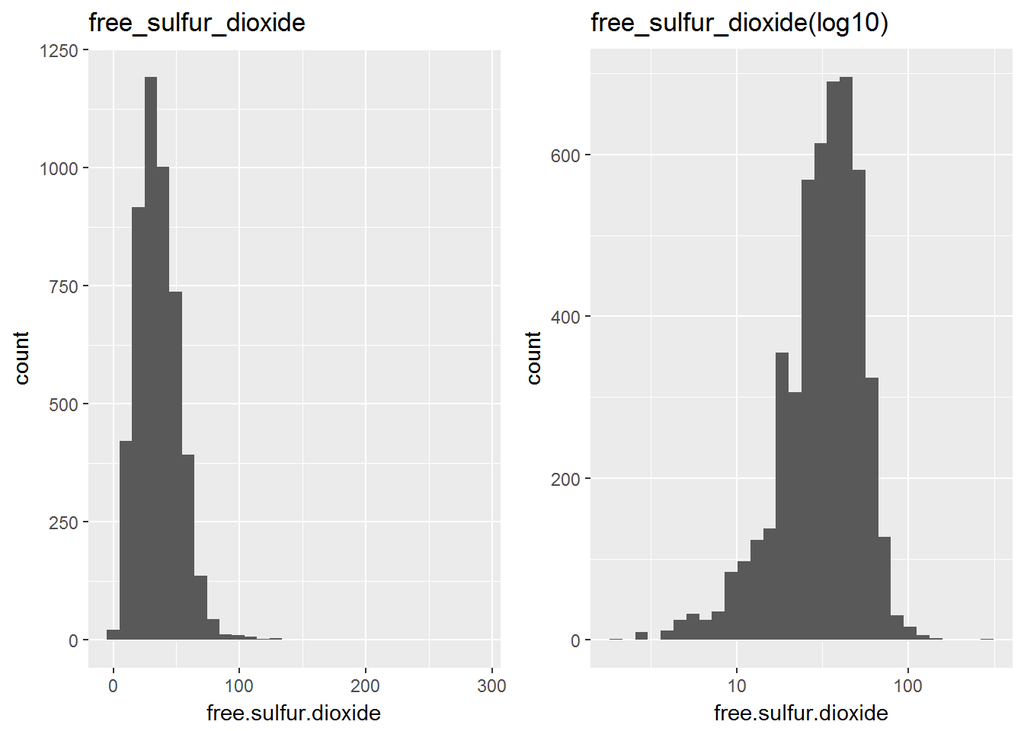

效果变化不大，右图10以下的部分由抖状上身变为右边缓状上升。

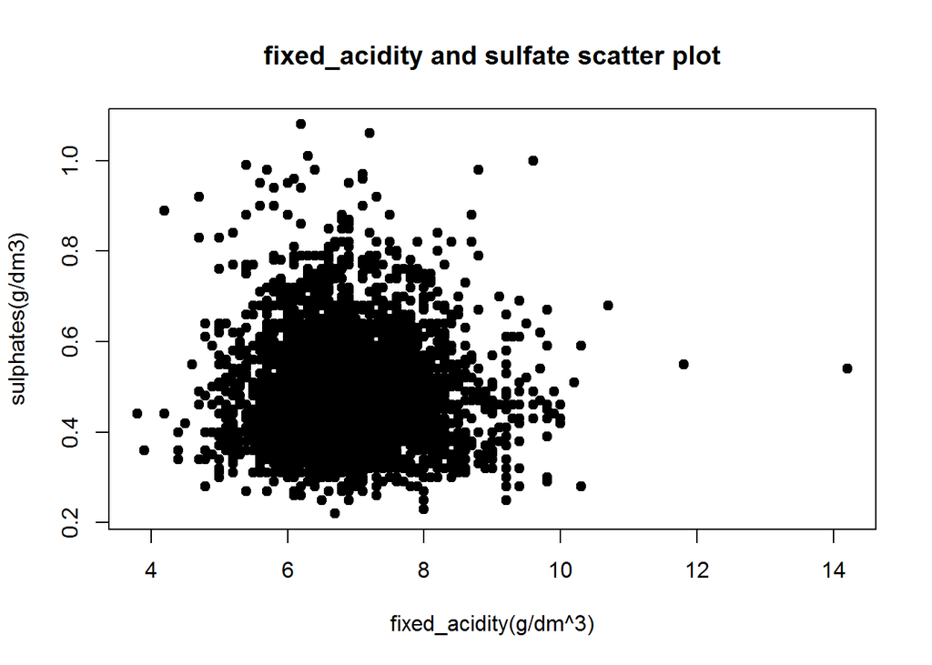

fixed.acidity和sulphates变量之间的散点图，数据主要集中在fixed.acidity的6-8之间。

# Bivariate Analysis

### Talk about some of the relationships you observed in this part of the investigation. How did the feature(s) of interest vary with other features in the dataset?

双变量分析中，两两变量的关系系数不大，数据离散度比较高。是想研究那些变量对“quality”的影响比较大，分析中这些变量的相关性比较大，“alcohol”(正相关)，“chlorides”、“density”、“total.sulfur.dioxide”、“volatile.acidity”这些变量和“quality均是呈现负相关。

### Did you observe any interesting relationships between the other features (not the main feature(s) of interest)?

“residual.sugar”和“density”变量的相关性较好,通过输出的结果可以预测等式： residual.sugar = -1407.85 + 1422.74density。

### What was the strongest relationship you found?

根据上面的分析，最强线性相关性两个变量，其中之一是“residual.sugar”和“density”，它们的一元线性回归方程的预测等式为： residual.sugar = -1407.85 +1422.74density；另外一个是 density和alcoholl两个变量表现出很强的负相关性，相关系数达到-0.78。

# Multivariate Plots Section

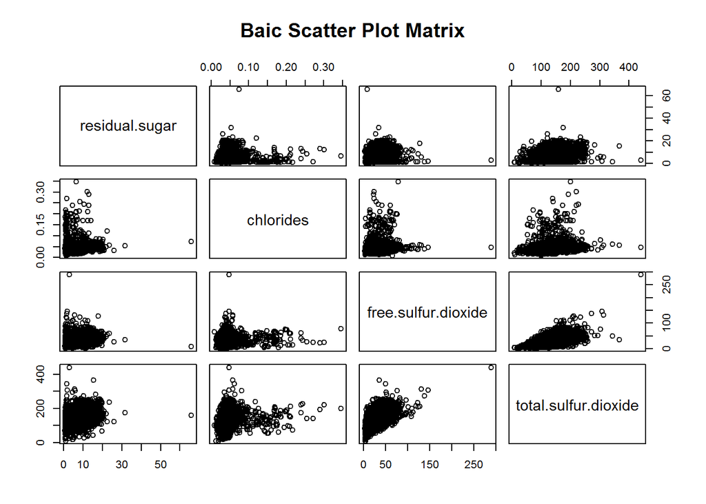

用pairs()函数创建的散点图矩阵，“residual.sugar”，“chlorides”，“free.sulfur.dioxide”和“total.sulfur.dioxide”四个变量之间的散点图矩阵，可以看到指定变量之间的二元关系。

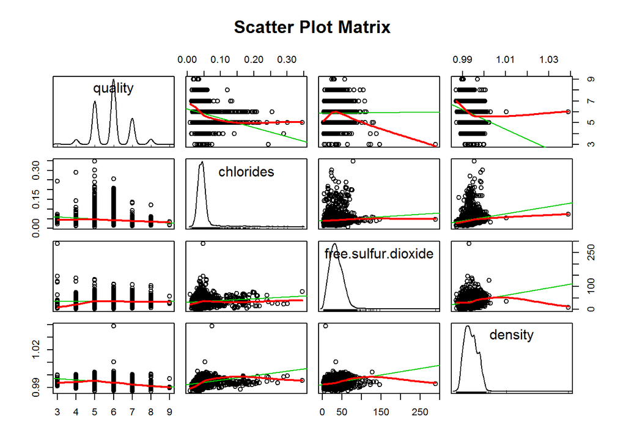

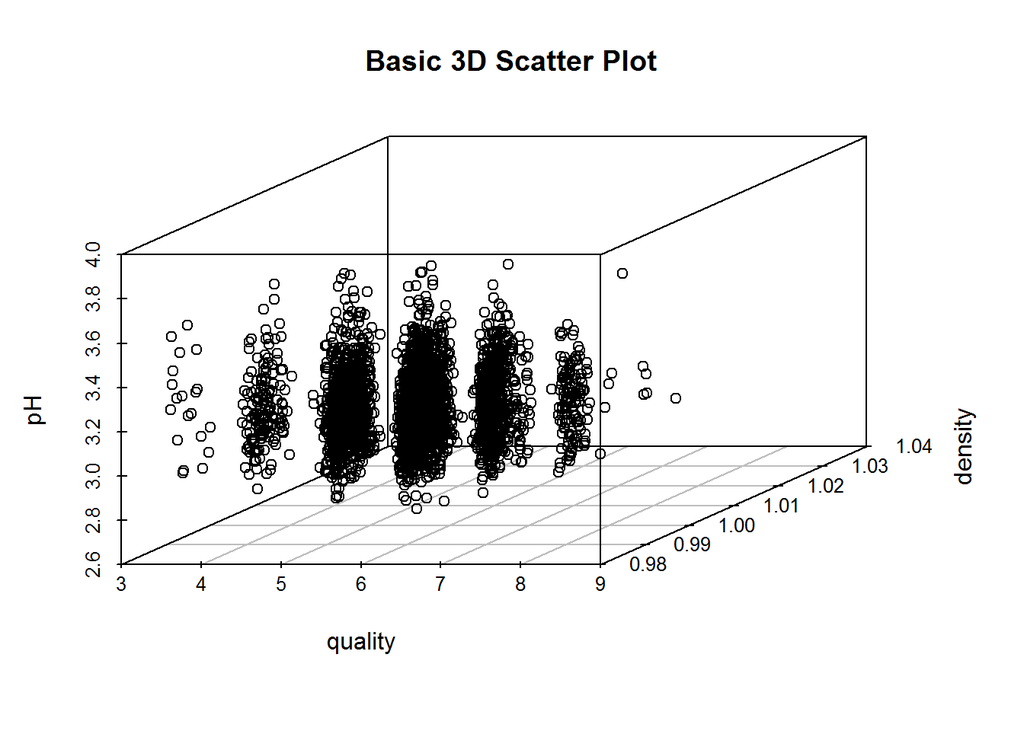

```
## [1] "C"
```

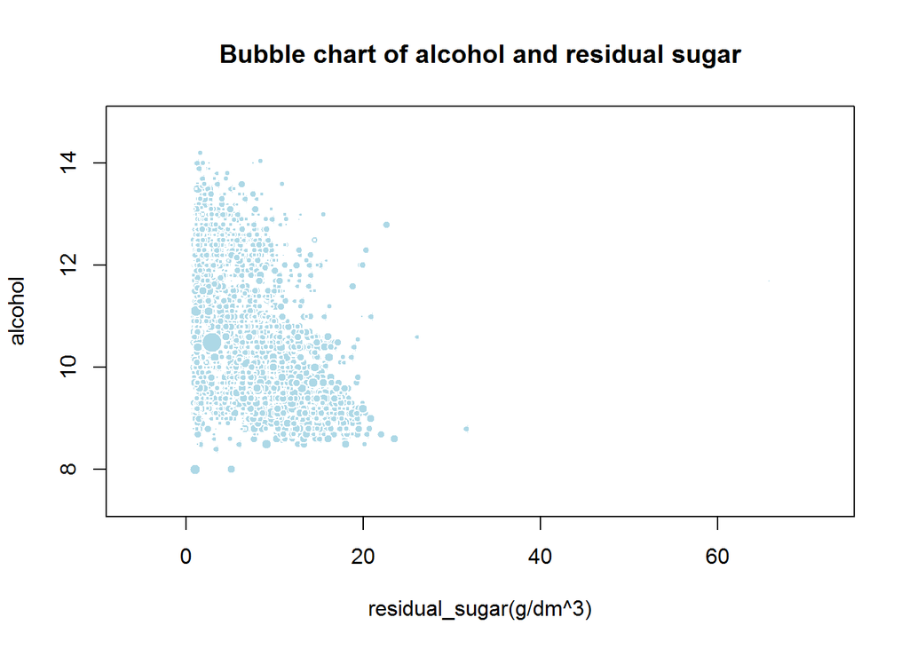

气泡图显示“free.sulfur.dioxide”，“residual.sugar”和“alcohol”三个变量的关系，其中变量“free.sulfur.dioxide”做了处理。里面可以看到一个比较大的图，该部分的数据量较为集中。

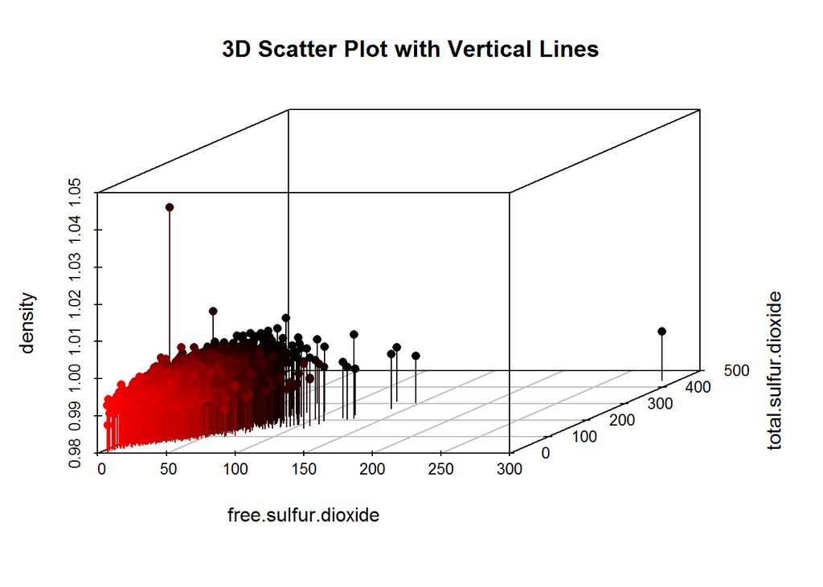

这是在三维散点图的基础上添加了连接点与水平面的垂直线，以突出显示效果。图中显示数据较为集中在坐标轴起点的区域，密集分布。

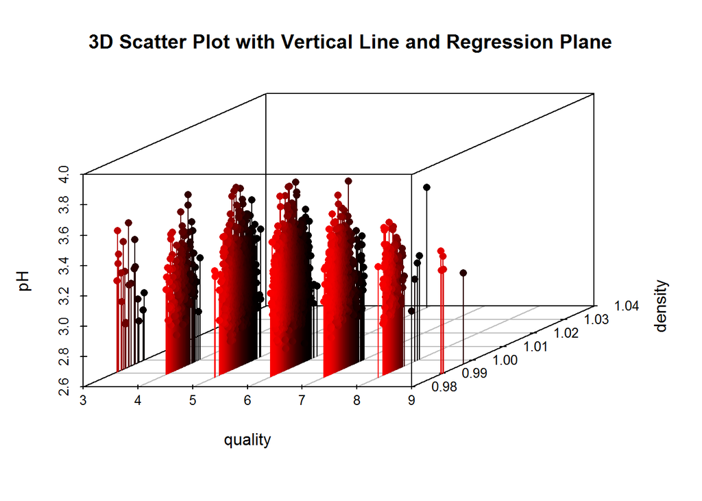

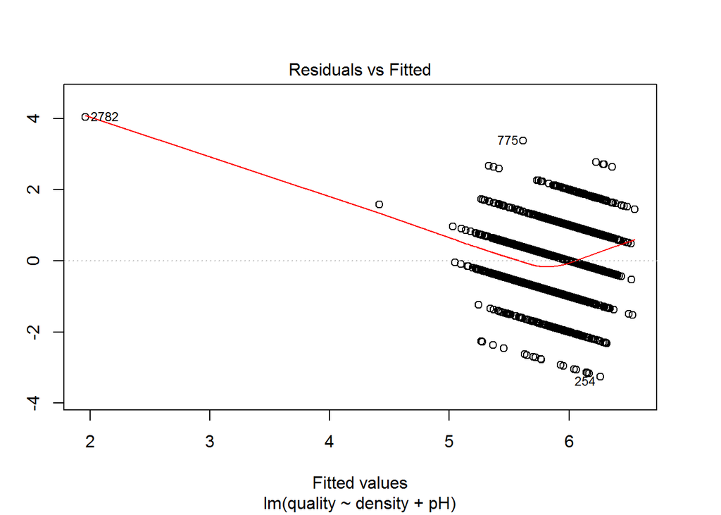

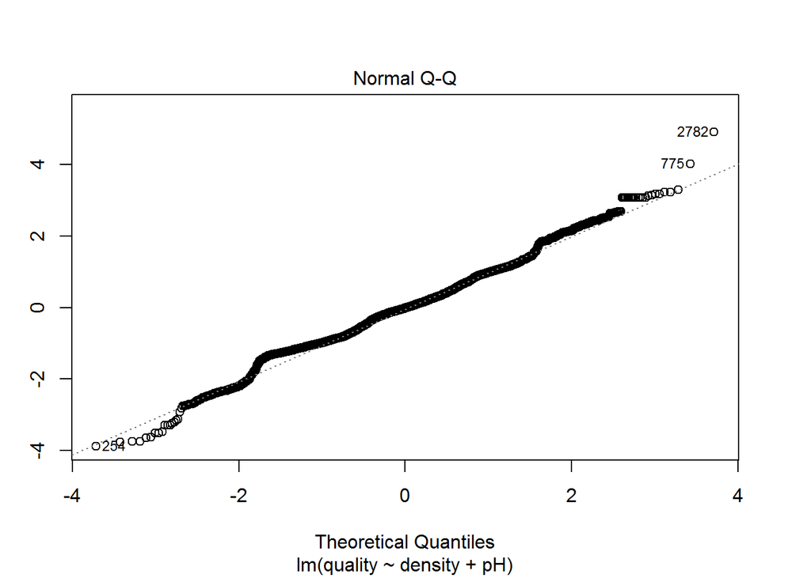